# Figure 2b: Drug combinations graph

This script prints Figure 2b: The thirty most common drug combinations represented as a graph.

Node size is proportional to the number of combinations per drug; combinations with more than 3 drugs are omitted for better visualization.

Drugs are represented in nodes coloured by drug indication. Drug combinations are shown in the network links. Combination pairs are represented by solid lines; triad combinations are represented by distinct dotted/dashed lines. Link width is proportional to the number of users per combination; colour corresponds to the number of potential drug effects. Combinations not tested are shown in gray.

Required file in the *input_data* folder:

- Supplementary_Tables_1_to_4_2019-09-13434.xlsx

Supplementary Tables 1 to 4 include information on the cohort characteristics and drug intake with source metadata. Source metadata for the MetaCardis cohort includes disease group, gender, age, study center, body mass index (BMI, kg/m2), alternative healthy eating index (aHEI), diet diversity score (DDS), and dietary approaches to stop hypertension (DASH), physical activity and manual work levels, and smoking status. Source data includes information on the drug intake, drug combinations, dosage and antibiotic use analyzed in the MetaCardis cohort.

- Supplementary_Table_8_2019-09-13434.xlsx

Supplementary Table 8: Features of microbiome, host and metabolome impacted by different drug combinations. Analysis of the effect of drug combinations, assessed for impact on host and microbiome falling within different measurement categories in each patient group.

- data_drugs_dict.txt

File containing the mapping between drug IDs in the metadata table and drug names and variable type

- drug.indication.tsv

File containing the mapping between drug name and indication.

Load required libraries.

```r
set.seed(0)
library(reshape2)
library(stringr)
library(dplyr)
library(arules)
library(arulesViz)
library(igraph)
library(ggplot2)
library(RColorBrewer)
library(checkmate)
library(readxl)
```

Load data required for plotting from files.

```r
folderName <- './input_data/'
d.out <- "./"
drug.indication <- paste(folderName, "drug.indication.tsv", sep="")
dic.anno <- paste(folderName, "data_drugs_dict.txt", sep="")

dir.create(d.out, showWarnings = F)

infilename <- 'Supplementary_Tables_1_to_4_2019-09-13434.xlsx'
# load patient drug uptake information
sampleData_drug <- as.matrix(read_excel(paste(folderName,infilename,sep=''),
                                 sheet = "ST 2b"))#,
# load patient metadata information
sampleData_meta <- as.matrix(read_excel(paste(folderName,infilename,sep=''),
                                        sheet = "ST 1b"))#,
# load drug combination intake information
sampleData_comb <- as.matrix(read_excel(paste(folderName,infilename,sep=''),
                                        sheet = "ST 3b"))#,
```

Define accessory functions.

```r
add.alpha <- function(col, alpha=1){
  if(missing(col))
    stop("Please provide a vector of colours.")
  apply(sapply(col, col2rgb)/255, 2,
        function(x)
          rgb(x[1], x[2], x[3], alpha=alpha))
}
```

Calculate the number of associations per drug from Supplementary Table 8

```r
infilename <- 'Supplementary_Table_8_2019-09-13434.xlsx'

combData <- as.matrix(read_excel(paste(folderName,infilename,sep=''),
                                 sheet = "Data"))#,

combData_unique <- unique((combData[,"Effector"]))

effects_all <- rep(0,length(combData_unique))
effects_same <- rep(0,length(combData_unique))
effects_opp <- rep(0,length(combData_unique))

first_array <- rep('NA',length(combData_unique))
second_array <- rep('NA',length(combData_unique))
third_array <- rep('NA',length(combData_unique))

for (i in 1:length(combData_unique)){
  test <- combData[combData[,'Effector']==combData_unique[i],'Congruence']
  effects_all[i] = length(test)
  effects_opp[i] = sum(test=='Opposite')
  effects_same[i] = sum(test=='Same')
  curdrugs = str_split(combData_unique[i],'intake', simplify = TRUE)
  first_drug = curdrugs[1]
  first_drug = str_replace(first_drug, 'Combination: ', '')
  first_drug = str_trim(first_drug)
  second_drug = curdrugs[2]
  second_drug = str_replace(second_drug, ', ', '')
  second_drug = str_trim(second_drug)

  first_array[i] = first_drug
  second_array[i] = second_drug

  if (length(curdrugs)>3){
    third_drug = curdrugs[3]
    third_drug = str_replace(third_drug, ', ', '')
    third_drug = str_trim(third_drug)
    third_array[i] = third_drug
  }
}

synergy <- data.frame(first_array, second_array, third_array,
                              effects_all, effects_same, effects_opp)
colnames(synergy) <- c("Drug1", "Drug2", "Drug3",
                              "AnySynergy", "SeverityMarker",   "HealthImprovement")
#replace text NA with numeric NA
synergy[synergy=='NA']=NA
```

Prepare data for processing.

```r
# prepare drug table
rownames(sampleData_drug) = sampleData_drug[, "SampleID"]
drop <- c( "SampleID" ,"PatientGroup","DRUGTOTAL")
sampleData_drug = sampleData_drug[,!(colnames(sampleData_drug) %in% drop)]

# prepare drug comb table
rownames(sampleData_comb) <- sampleData_comb[, "SampleID"]
drop <- c( "SampleID" ,"PatientGroup")
sampleData_comb = sampleData_comb[,!(colnames(sampleData_comb) %in% drop)]

# prepare metadata
colnames(sampleData_meta)[2:6]<-c("PATGROUPFINAL_C", "GENDER", "BMI_C", "AGE", "CENTER_C")
rownames(sampleData_meta) <- sampleData_meta[, "SampleID"]

sample_extended_meta <- merge(sampleData_meta, sampleData_comb, by="row.names", all=TRUE)
drop <- c( "Row.names")
sample_extended_meta = sample_extended_meta[,!(colnames(sample_extended_meta) %in% drop)]
```

Load data files for indication and drug abbreviations.

```r
# load drug abbreviation dictionary
dic.anno <- read.delim(dic.anno, stringsAsFactors = F)

# load rug indication info
drug.indication = read.delim(drug.indication, stringsAsFactors = F)

drugs <- sampleData_drug
metadata <- sample_extended_meta
```

Edit Dictionary.

```r
dic.anno <- dic.anno %>%
  mutate(DisplayName = str_replace(DisplayName, " intake", ""))
```

Edit input data.

```r
## Filter out healthy patients
metadata <- metadata[ metadata$PATGROUPFINAL_C != "8",]
drugs <- drugs[match(metadata$SampleID, rownames(drugs)) ,]
identical(metadata$SampleID %>% as.character(), rownames(drugs))
```

```
## [1] TRUE
```

```r
## Remove collective drugs
drugs <- drugs [, !colnames(drugs) %in%
                  dic.anno[dic.anno$DisplayName %in%
                             c("Antibiotics total",
                               "Unknown antibiotic",
                               "Any antilipid treatment",
                               "Any antihypertensive treatment",
                               "Any antidiabetic treatment"),
                           "VariableID"]]
```

Sync data with dictionary.

```r
drugs <- drugs[,colnames(drugs) %in% dic.anno$VariableID]
dic.anno <- dic.anno[match(colnames(drugs), dic.anno$VariableID),]
identical(dic.anno$VariableID, colnames(drugs))
```

```
## [1] TRUE
```

Format data

```r
## Rename columns to be the display variable
colnames(drugs) <- dic.anno$DisplayName

# Get frequent items ----
## Format data input
drugs.d <- drugs
drugs.d <- as.data.frame(drugs.d > 0)

## Mine frequent itemsets with the Eclat algorithm
freq.all=eclat(drugs.d,parameter=list(supp = 0.05))
```

```
## Eclat
##
## parameter specification:
##  tidLists support minlen maxlen            target  ext
##     FALSE    0.05      1     10 frequent itemsets TRUE
##
## algorithmic control:
##  sparse sort verbose
##       7   -2    TRUE
##
## Absolute minimum support count: 93
##
## create itemset ...
## set transactions ...[33 item(s), 1878 transaction(s)] done [0.00s].
## sorting and recoding items ... [17 item(s)] done [0.00s].
## creating bit matrix ... [17 row(s), 1878 column(s)] done [0.00s].
## writing  ... [106 set(s)] done [0.00s].
## Creating S4 object  ... done [0.00s].
```

```r
# ## Get clean data
freq.list <- utils::capture.output(inspect(freq.all))
test = ''
for(i in 1:length(freq.list)){
  test<-paste(test, freq.list[i],sep=' ')
  }
freq.list <- strsplit(test, '\\{[^}]+ (*SKIP)(*FAIL)| \\s*', perl=TRUE)[1]
dd  <-  as.data.frame(t(matrix(unlist(freq.list), nrow=5, byrow=FALSE)))
dd <- dd[,-1]
names(dd) <- as.character(unlist(dd[1,]))
dd <- dd[-1,]
freq.list <- dd[-1,]
## End of Get clean data
# note: if running this code in console, instead of the code in Get clean data use
#freq.list <- as.data.frame(inspect(freq.all))
freq.list$items <- gsub("\\{", "", freq.list$items)
freq.list$items <- gsub("\\}", "", freq.list$items)
freq.list$items <- gsub("\\s+", " ", freq.list$items)
freq.list$items <- gsub(", ", ",", freq.list$items)
freq.list$support <- as.numeric(as.character(freq.list$support))
freq.list$transIdenticalToItemsets <- as.numeric(as.character(freq.list$transIdenticalToItemsets))
freq.list$count <- as.numeric(as.character(freq.list$count))
```

Write raw output.

```r
#UNCOMMENT TO PRINT FREQUENCIES TO FILE
#f.name <- paste(d.out, "frequent.list.5.tsv", sep = "")
#write.table(freq.list, f.name, row.names = F, sep = "\t", quote =F )
```

Annotate number of drugs in freq-items co-usage.

```r
freq.list <- freq.list %>%
  mutate (n = str_count(items, ",") + 1)
```

Filter what to plot in the network.

```r
to.net <- freq.list %>%
  # Keep combinations with up to 3 drugs
  filter(n <= 3, n > 1)

to.net$id = 0
synergy$id = 1:nrow(synergy)
```

Identify which freq items have synergy information by common id.

```r
for (x in 1:nrow(to.net)){
  set1 = to.net[x, "items"]
  set1 = str_split(set1, ",")[[1]]
  set1 = str_trim((set1))
  for (y in 1:nrow(synergy)){
    set2 = synergy[y,c("Drug1", "Drug2", "Drug3")]
    set2 = set2[!is.na(set2)]
    if(testSetEqual(set1, set2, ordered = F)){to.net$id[x]=synergy$id[y]}
    }
}
```

Filter network by count and add synergy information.

```r
top = 30

to.net <- synergy %>%
  select(-Drug1, -Drug2, -Drug3) %>%
  right_join(to.net) %>%
  top_n(n = top, wt = count)
# Define cbind/fill function as in https://gist.github.com/abelsonlive/4112423
cbind.fill<-function(...){
    nm <- list(...)
    nm<-lapply(nm, as.matrix)
    n <- max(sapply(nm, nrow))
    do.call(cbind, lapply(nm, function (x)
    rbind(x, matrix(, n-nrow(x), ncol(x)))))
}
```

Format it to plot.

```r
## Get from and to edges
df.convoluted <- NULL
x <- 0
for (i in 1:nrow(to.net)){
its <- as.character(to.net[i,"items"])
its <-  str_split(its, ",")[[1]]
n <- length(its)
x <- x+1
if (n > 1) {
  its <- cbind(t(combn(its, 2)), code = x) %>%
    data.frame(stringsAsFactors = F)
  colnames(its) <- c("from", "to", "code")
  its <- as.data.frame(cbind.fill(its, to.net[i,]))
  df.convoluted <- rbind(df.convoluted,
                         its)
  }
}

## Transform info as character

df.convoluted <- df.convoluted %>%
  mutate(from = as.character(from),
         to =  as.character(to),
         code = as.character(code))

## Add edge with
x = 1
df.convoluted$edge.lty <- 1
for (i in unique(df.convoluted$code)){
  d.temp <- df.convoluted[df.convoluted$code == i,]
  if(nrow(d.temp) > 1){x <- x+1
  df.convoluted[df.convoluted$code == i, "edge.lty"] <- x}
}

## Vertex width
vert <- c(df.convoluted$from, df.convoluted$to) %>%
  unique() %>%
  sort() %>%
  data.frame(stringsAsFactors = F)
colnames(vert) = "vert"
vert <- vert %>%
  left_join(freq.list, by = c("vert" = "items")) %>%
  left_join(drug.indication,
            by = c("vert" = "Drug"))
```

Build network.

```r
net  <- graph_from_data_frame(d = df.convoluted, vertices = vert, directed=F)
```

Make cosmetic additions to it.

```r
## Make gradient of colors
rbPal <- colorRampPalette(c("#43C6AC","#191654"))
df.convoluted$Col <- add.alpha(rbPal(10)[
  as.numeric(cut(as.numeric(as.character(df.convoluted$HealthImprovement)), breaks = 10))], 0.8)
# #Mod color of NAs
col.2 <- add.alpha("#545454", 0.8)
df.convoluted <- df.convoluted %>%
  mutate(Col = if_else(is.na(HealthImprovement), col.2, Col))
```

```r
## Colors of nodes
n.col = length(unique(vert$Indication))
pal <- brewer.pal(n = 8, name = "Dark2")[c(1:3,5:6)]
pal <-  colorRampPalette(pal)(n.col)

## Get degrees
deg <- igraph::degree(net, mode="all")
```

```r
## Config vertex
V(net)$size=sqrt(deg-0.20)*9
V(net)$label.family="Helvetica"
V(net)$frame.color = NA
V(net)$label.color = "black"
V(net)$color = pal[as.numeric(factor(vert$Indication))]
V(net)$label.cex <- 1.2
```

```r
## Config edge
E(net)$label.dist=-2
E(net)$label.cex = 0.9
E(net)$label.colour = rep("black", nrow(df.convoluted))

E(net)$width = as.numeric(as.character(df.convoluted$count))/40

E(net)$color <- df.convoluted$Col
E(net)$label.color = "darkgray"

E(net)$lty <- df.convoluted$edge.lty
l <- layout_with_kk(net)
l <- layout_in_circle(net)
```

#Plot

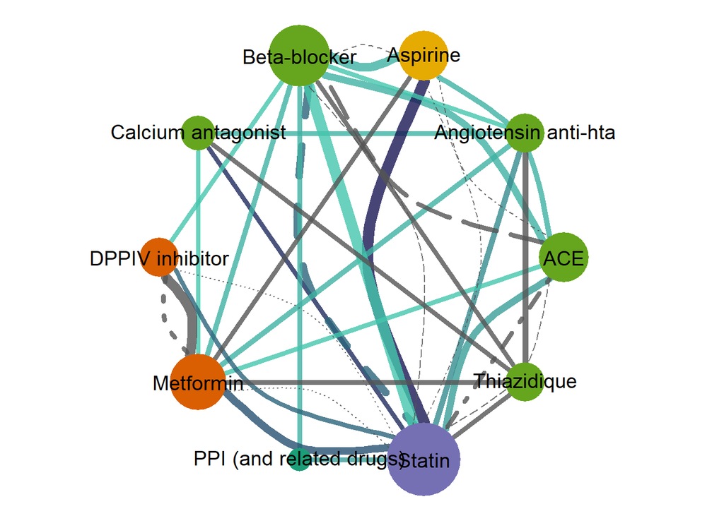

```r
par(mar=c(0,0,0,0))
plot(net, layout=l,
    edge.label.color = "darkgrey")#edge.label.family = "Arial")
```

```r
## UNCOMMENT TO PRINT TO FILE
#f.name <- paste(d.out, "fig2b_network.pdf", sep ="/")
#pdf(f.name)
#par(mar=c(0,0,0,0))
#plot(net, layout=l,
#    edge.label.color = "darkgrey",
#    edge.label.family = "Helvetica")
#dev.off()
```

Plot legends separately

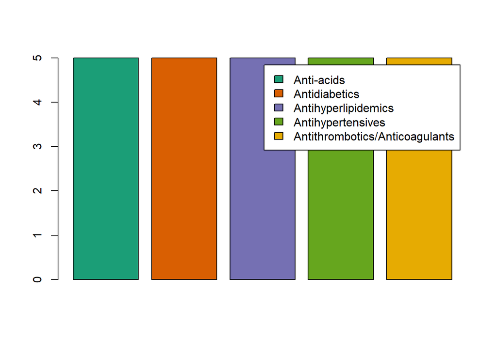

```r
## Legend colors vertex
vert.unique <- vert %>%
  select(n, Indication) %>%
  unique()

#f.name <- paste(d.out, "network.legend.1.pdf", sep ="/")
#pdf(f.name)
barplot(rep(5, nrow(vert.unique)), col = pal, legend.text = vert.unique$Indication %>% sort())
```

```r
#dev.off()
```

Legend colors edge

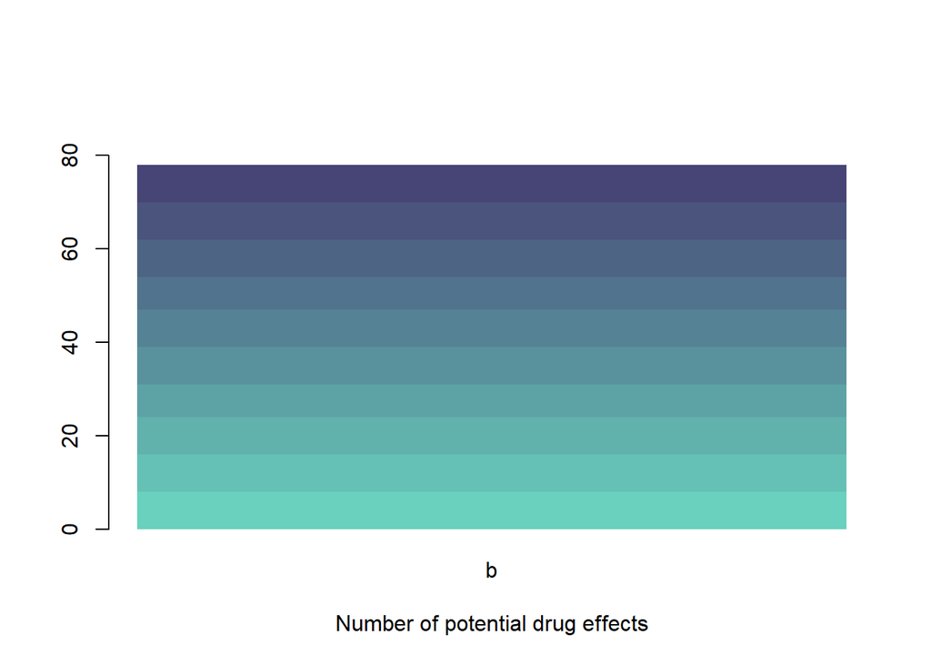

```r
values  <- seq(from = min(as.numeric(as.character(df.convoluted$HealthImprovement)), na.rm = T),
    to = max(as.numeric(as.character(df.convoluted$HealthImprovement)), na.rm = T))
rbPal <- colorRampPalette(c("#43C6AC","#191654"))
col.legend <- add.alpha(rbPal(10)[
  as.numeric(cut(values, breaks = 10))], 0.8)
col.legend <- data.frame(values, col.legend, stringsAsFactors = F)
col.legend$v <- rep(1, nrow(col.legend))

#f.name <- paste(d.out, "network.legend.2.pdf", sep ="/")
#pdf(f.name)

barplot(as.matrix(data.frame(b = col.legend$v)),
        col = col.legend$col.legend, ylim = c(0, 90), beside = F,
        border=NA, space=0, xlab = 'Number of potential drug effects')
```

```r
#dev.off()
```